# Econ_631_Project_Report_PallaviAythaSwathi

Pallavi

29/04/2020

Absenteeism at work.

Absenteeism is defined as absence to work as expected, represents for the company the loss of productivity and quality of work. Workers in the factory are absent from work for various reasons. My client is Hanh Nong, who is the head of a factory belonging to a Cosmetic Company that produces cosmetic products. She has a couple of questions:

Question 1: What is the most impacting reason for the workers to be absent? Question 2: Is there a relation between age and the number of absent hours of the worker?

From these questions, the client would like to assertain if there can be policy changes in the company that can help workers and reduce the number of absent hours.

The data has many numeric values. These values are not useful in the visualizations and do not make for readable visualizations for the client. I modified these visualizations into understandable values which makes it easier for me and the client to read and understand.

Data Explorations: Below are some data explorations from the data, there are significantly more number of people in the dataset with lesser number of pets and kids.

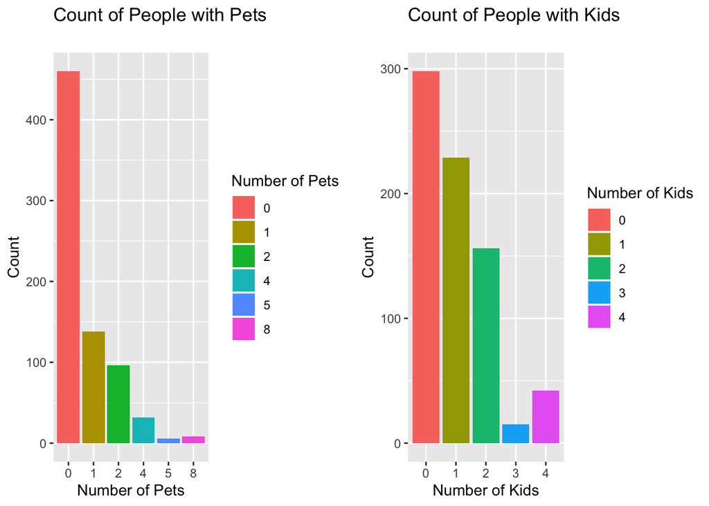

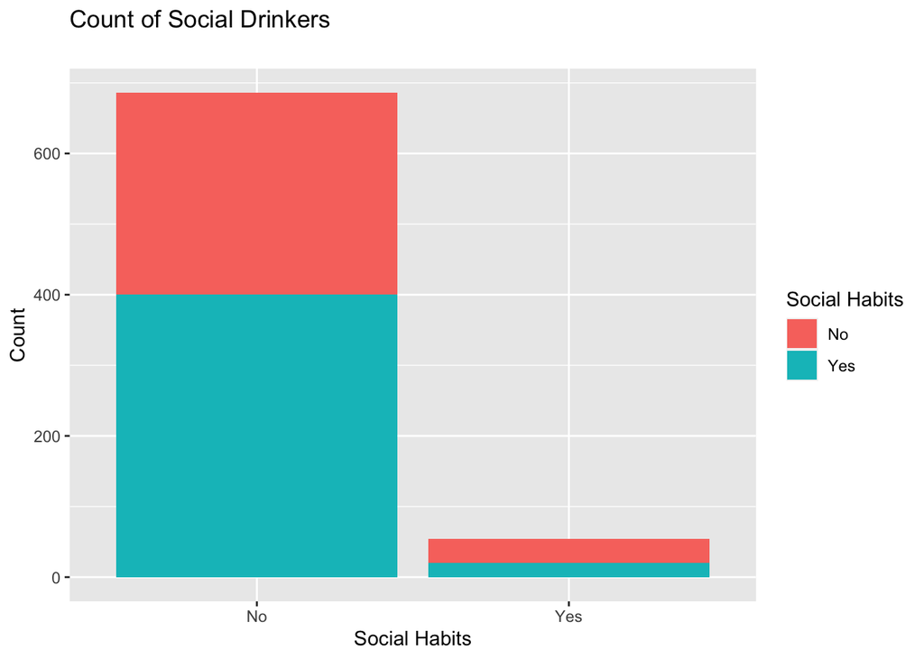

The distributions below shows the distributions of days of week in the dataset.

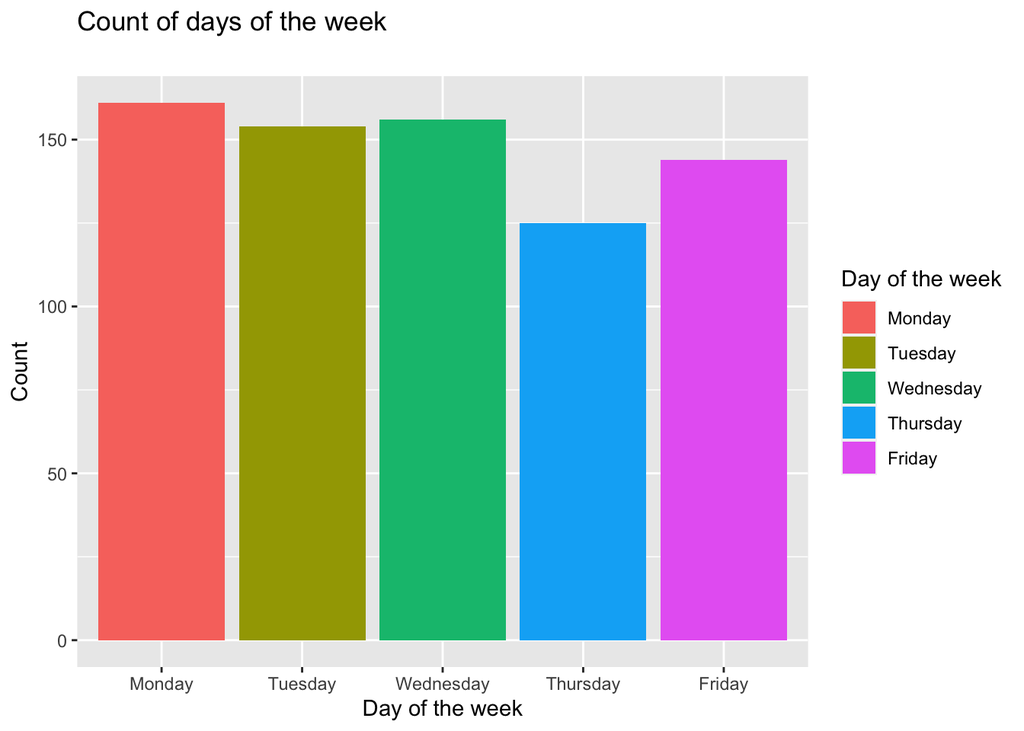

The visualization below show the reasons for workers to be absent. The top reason for the worker to be absent seems to be medical consultation. The max number of reasons for the workers to be absent seems to be health related. Can we say that the workers might be stressed? The client can make sure the workers are not stressed by organising events that can help in team building along with being enjoyable. This can help motivate the workers to come to work.

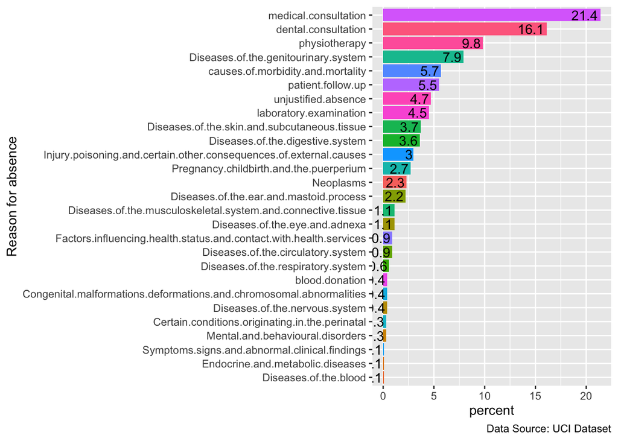

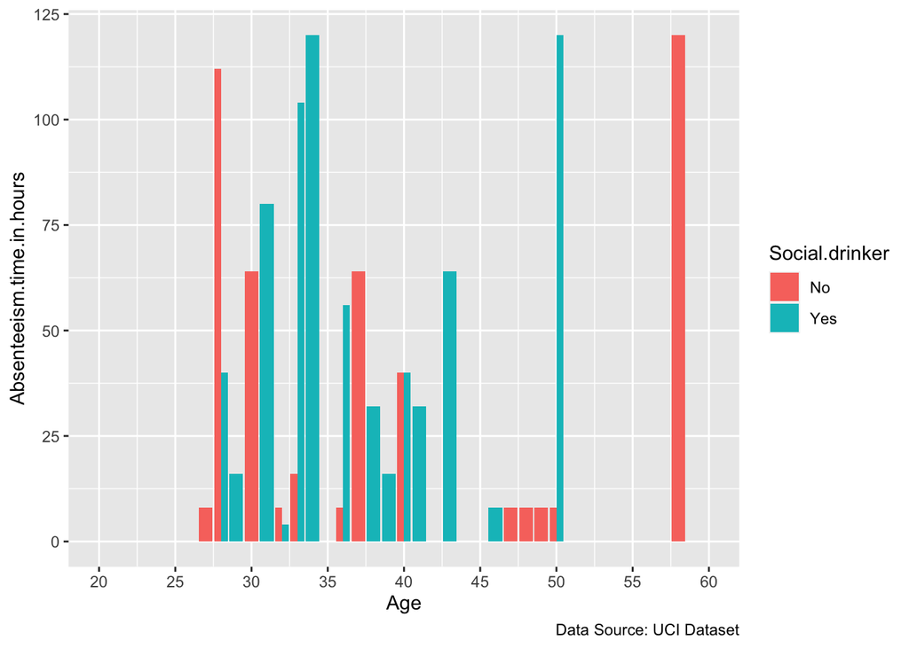